# Day4 Bivariate Viz Plots

STAT/COMP 112, secs. 2 and 3

2024-01-30

# Code for the Bivariate Quantitative Plots

Below is the code which produced the scatterplots displayed in the Class notes for Day 4.

First, an unadorned scatterplot of the elo data

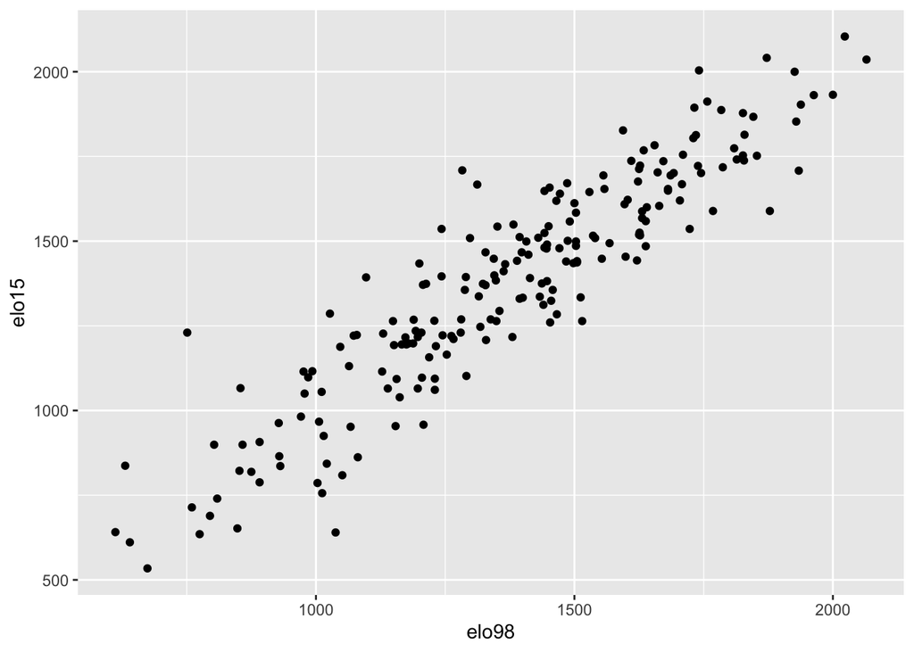

```r
library(tidyverse)
library(fivethirtyeight)

ggplot(elo_blatter,aes(x=elo98,y=elo15)) +
  geom_point()
```

Here is the same plot with the point representing USA highlighted

Note: we have also labelled the point. This was done using the package **gghighlight**.

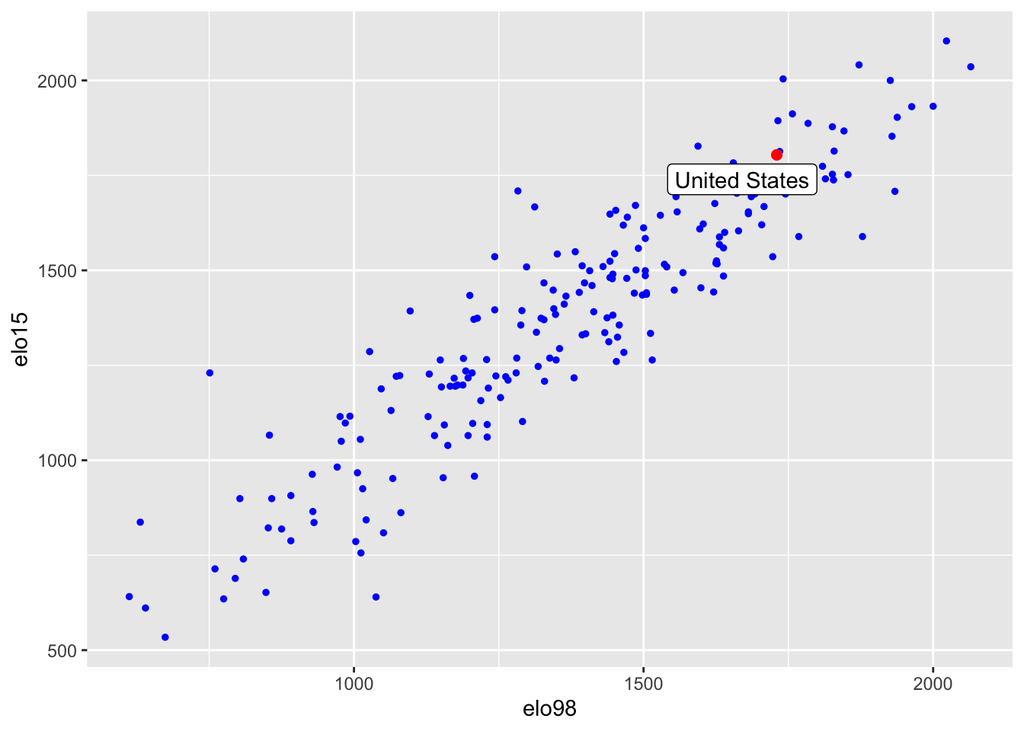

```r
library(gghighlight)

ggplot(elo_blatter,aes(x=elo98,y=elo15)) +
  geom_point(color="red",size=2) +
  gghighlight(country=="United States",label_key = country,
              unhighlighted_params = list(color="blue",size=1))
```

# Code for the Bivariate Categorical Plots

Below is the code which produced the barplots displayed in the notes for Day 4.

```r
library(ISLR2)

str(Auto)
```

```
## 'data.frame':    392 obs. of  9 variables:
##  $ mpg         : num  18 15 18 16 17 15 14 14 14 15 ...
##  $ cylinders   : int  8 8 8 8 8 8 8 8 8 8 ...
##  $ displacement: num  307 350 318 304 302 429 454 440 455 390 ...
##  $ horsepower  : int  130 165 150 150 140 198 220 215 225 190 ...
##  $ weight      : int  3504 3693 3436 3433 3449 4341 4354 4312 4425 3850 ...
##  $ acceleration: num  12 11.5 11 12 10.5 10 9 8.5 10 8.5 ...
##  $ year        : int  70 70 70 70 70 70 70 70 70 70 ...
##  $ origin      : int  1 1 1 1 1 1 1 1 1 1 ...
##  $ name        : Factor w/ 304 levels "amc ambassador brougham",..: 49 36 231 14 161 141 54 223 241 2 ...
##  - attr(*, "na.action")= 'omit' Named int [1:5] 33 127 331 337 355
##   ..- attr(*, "names")= chr [1:5] "33" "127" "331" "337" ...
```

```r
names(Auto)
```

```
## [1] "mpg"          "cylinders"    "displacement" "horsepower"   "weight"
## [6] "acceleration" "year"         "origin"       "name"
```

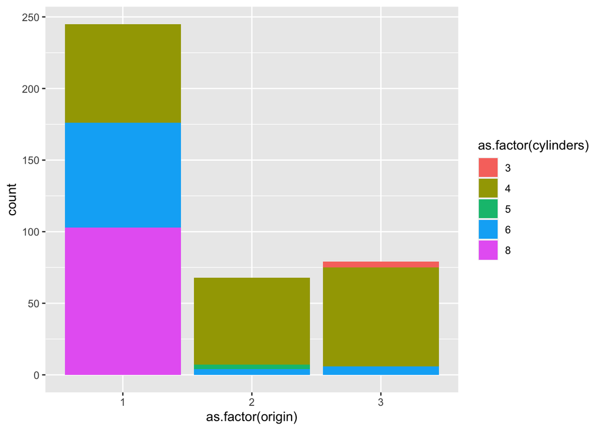

```r
## Note in the commands below, in the aesthetic we use the option
## fill = <second variable>     to make the colored bar segments

ggplot(Auto,aes(x=as.factor(origin),fill=as.factor(cylinders)))+
  geom_bar()
```

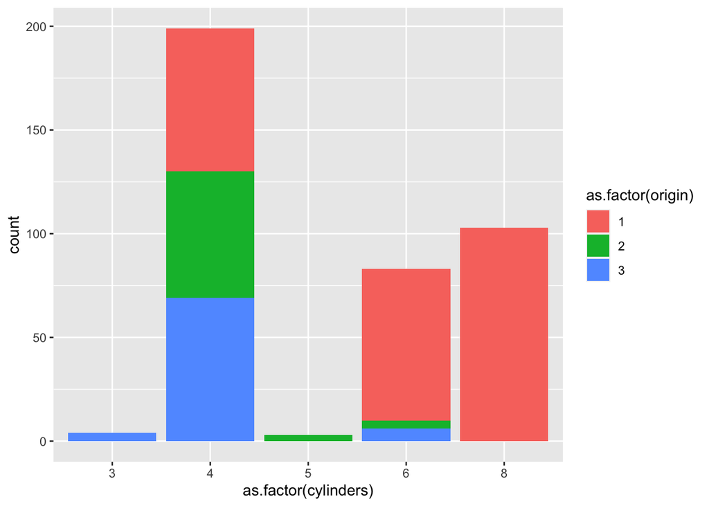

```r
ggplot(Auto,aes(x=as.factor(cylinders),fill=as.factor(origin)))+
  geom_bar()
```

# Day 4 Exercises

Create a new .rmd file called **Day 4 Exercises** and do these problems in that markdown document

in the first code chunk of your document you will need to load in the packages containing the data. so run

**library(fivethirtyeight)**

and

**library(ISLR2)**

## Exercise 1

Using code similar to the highlighted scatterplot for the elo rankings, replace the option

*country = “United States”* with *confederation = “CONMEBOL”*

also replace *size = 2* with *size = 3* in the geom_point() options

Explain what these changes do to the plot.

Now do the same thing for the confederation *CONCACAF* (this is the federation to which the USA belongs).

Describe similarities and differences that you see between the elo rankings of the countries in the two federations.

Also, how is the second plot different from the first, and can you explain why it is different?

```
## Too many data points, skip labeling
```

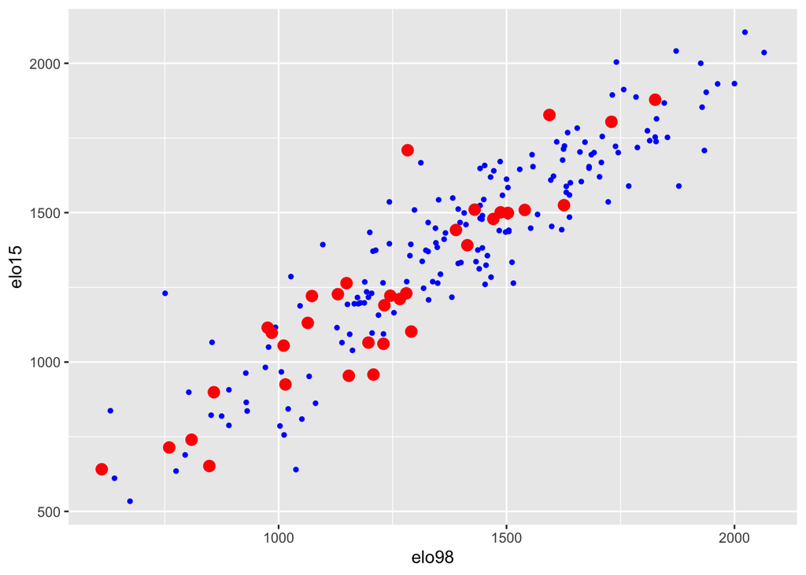

```r
ggplot(elo_blatter,aes(x=elo98,y=elo15)) +
  geom_point(color="red",size=3) +
  gghighlight(confederation=="CONCACAF",label_key = country,
              unhighlighted_params = list(color="blue",size=1))
```

In the ISLR2 repository of data there is a dataset called **BrainCancer** which has 5 categorical variables with each with four or fewer categories. Using different pairs of variables make *at least three* segmented barplots using these variables and describe what these plots tell you about the relationships between the variables.

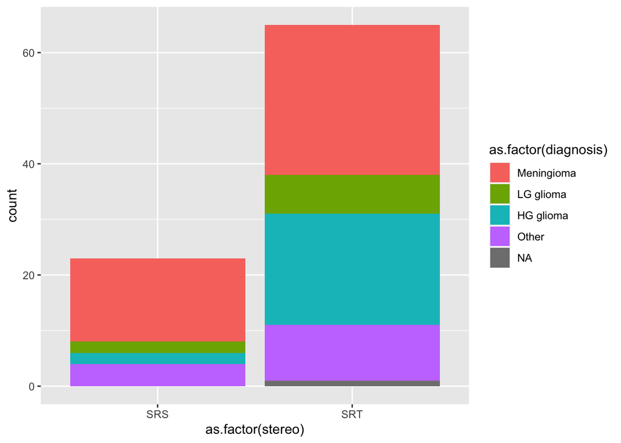

```r
ggplot(BrainCancer,aes(x=as.factor(stereo),fill=as.factor(diagnosis)))+
  geom_bar()
```

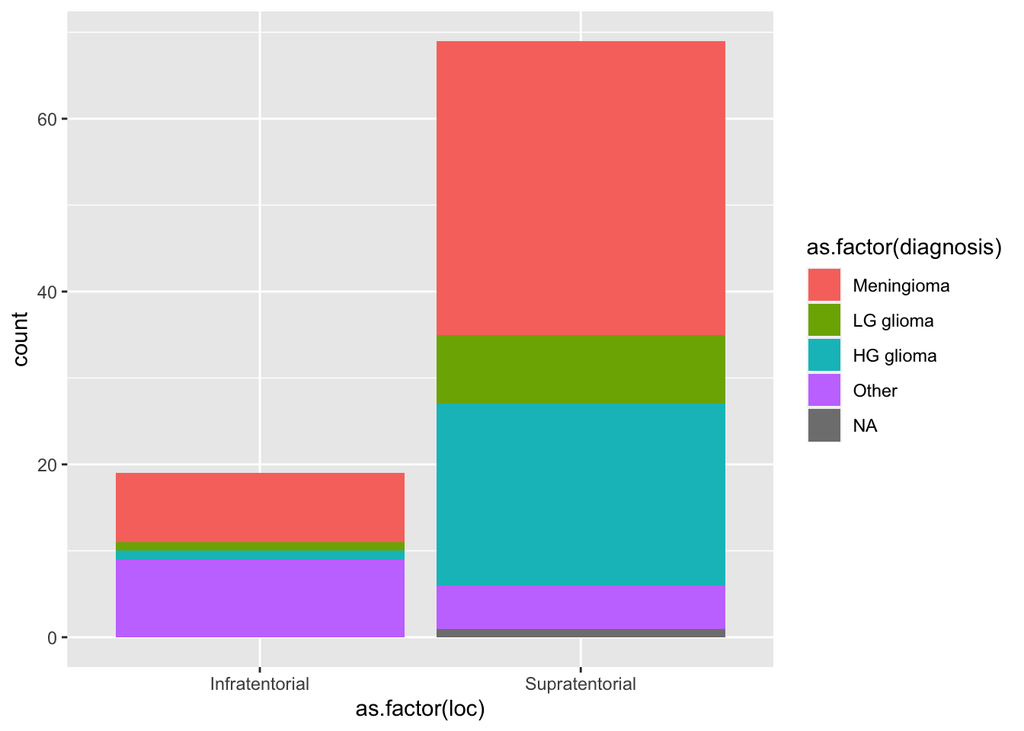

```r
ggplot(BrainCancer,aes(x=as.factor(loc),fill=as.factor(diagnosis)))+
  geom_bar()
```

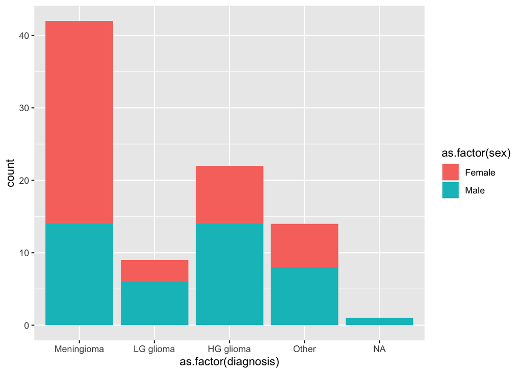

```r
ggplot(BrainCancer,aes(x=as.factor(diagnosis),fill=as.factor(sex)))+
  geom_bar()
```

SRS seems to have a lower total diagnosis number than SRT screening

most of the cancers have a higher rate in supratertorial location vs infratentorial except for the other catergory

Females seem to have higher rates of cancer in Meninioma, but in all other categories the males seem to have higher rates when compared to women